# Analyzing FitBit Data

Khawar Siddiqui

3 DEC 2016

### 0.0.1 Analysis of Data from Personal Activity Monitoring Device (FitBit)

This document attempts to answer questions in the light of analysis of data collected by a Personal Monitoring Device [FitBit](http://en.wikipedia.org/wiki/Fitbit). This is the first project for the **Reproducible Research** course in Coursera’s Data Science specialization track.

## 0.1 The Assignment

The assignment was meant to serve as a hands on training in:

- loading and pre-processing a data set using R or R-Studio
- imputing missing values in the data set
- interpreting the results and answer research questions

## 0.2 About The Data

The data for this assignment was downloaded from:

- **Dataset**: Personal Activity Monitoring data from Dataset: [Activity monitoring data](https://d396qusza40orc.cloudfront.net/repdata%2Fdata%2Factivity.zip) [52K]. The data was in the form of a .csv file archived as a zip file. The variables of dataset are as below:
- **steps**: Number of steps walked in a 5-minute interval (missing values are coded as `NA`)
- **date**: The date on which the measurement was taken in YYYY-MM-DD format
- **interval**: Identifier for the 5-minute interval in which measurement was taken

The dataset is stored in a comma-separated-value (CSV) file and there are a total of 17,568 observations in this dataset.

## 0.3 Loading and pre-processing the data for analysis

```r
library(ggplot2)
library(lattice)
library(knitr)

# Loading and Processing
if(!file.exists("getdata-projectfiles-UCI HAR Dataset.zip")) {
        temp <- tempfile()
        download.file("http://d396qusza40orc.cloudfront.net/repdata%2Fdata%2Factivity.zip",temp)
        unzip(temp)
        unlink(temp)
}


actMonData_00<-read.csv("activity.csv")
```

## 0.4 What is mean total number of steps taken per day?

Totalling the steps taken by day, making histogram, and then calculating the mean and the median.

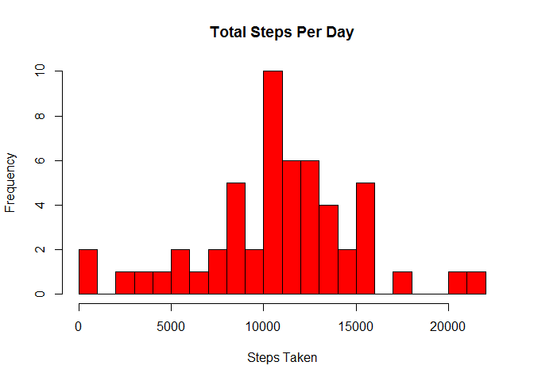

```r
    # Mean and Median Number of Total Steps Per Day
    stepsPerDay <- aggregate(steps ~ date, data=actMonData_00, sum, na.rm = TRUE)
    hist(stepsPerDay$steps, breaks=25, main = paste("Total Steps Per Day"), col="red", xlab="Steps Taken", ylab="Frequency")
```

```r
    mean_stepsPerDay <- mean(stepsPerDay$steps)
    median_stepsPerDay <- median(stepsPerDay$steps)
    print(paste("The mean steps per day is: ", mean_stepsPerDay))
```

```
## [1] "The mean steps per day is:  10766.1886792453"
```

```r
    print(paste("The median steps per day is: ", median_stepsPerDay))
```

```
## [1] "The median steps per day is:  10765"
```

## 0.5 What is the average daily activity pattern?

1 Calculate average steps for each interval for all days. 2 Plot the Average Number Steps per Day by Interval. 3 Find interval with most average steps.

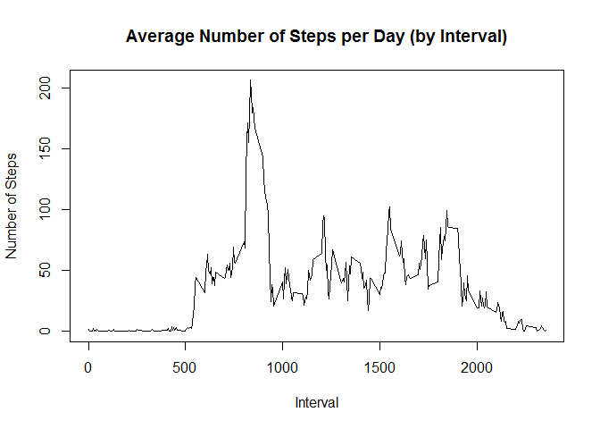

```r
    stepsPerInterval <- aggregate(steps ~ interval, actMonData_00, mean)
    plot(stepsPerInterval$interval,stepsPerInterval$steps, type="l", xlab="Interval", ylab="Number of Steps",main="Average Number of Steps per Day (by Interval)")
```

```r
    intervalWithMaxSteps <- stepsPerInterval[which.max(stepsPerInterval$steps),1]
    print(paste("Time Interval with Maximum Steps: ", intervalWithMaxSteps))
```

```
## [1] "Time Interval with Maximum Steps:  835"
```

## 0.6 Imputing the missing values.

## 0.7 Comparing the imputed with non-imputed data.

There were numerous missing values in the data set. The missing values were imputed using the median as the data might not be normal.

```r
    # Impute missing values. Compare imputed to non-imputed data.
    missings <- sum(is.na(actMonData_00$steps))
    print(paste("There are", missings, "missing data points."))
```

```
## [1] "There are 2304 missing data points."
```

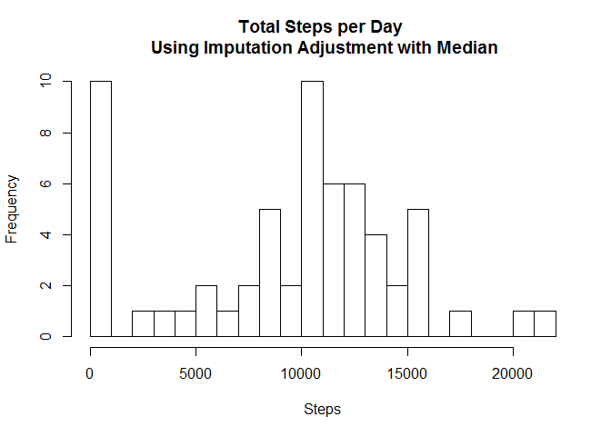

```r
    imputedData <- actMonData_00
    imputedData$steps[is.na(imputedData$steps)] <- median(actMonData_00$steps, na.rm=TRUE)
    imputedDataday <- aggregate(steps ~ date, data=imputedData, sum, na.rm=TRUE)
    hist(imputedDataday$steps, breaks=20, main="Total Steps per Day \n Using Imputation Adjustment with Median",
         xlab="Steps", ylab="Frequency")
```

```r
    imputedMean <- mean(imputedData$steps)
    imputedMedian <- median(imputedData$steps)
    print(paste("The mean is: ", imputedMean))
```

```
## [1] "The mean is:  32.4799635701275"
```

```r
    print(paste("The median is: ", imputedMedian))
```

```
## [1] "The median is:  0"
```

```r
    meanDifference<- imputedMean-mean_stepsPerDay
    medianDifference <- imputedMedian-median_stepsPerDay
    print(paste("The difference between the imputed and original mean is: ", meanDifference))
```

```
## [1] "The difference between the imputed and original mean is:  -10733.7087156752"
```

```r
    print(paste("The difference between the imputed median and the original median is: ", medianDifference))
```

```
## [1] "The difference between the imputed median and the original median is:  -10765"
```

## 0.8 Visualizing differences in activity patterns between weekdays and weekends?

Below is a plot to compare the number of steps counted between the week and weekend. As it is evident from the graph, there is a higher activity in earlier hours on weekdays, and the weekends are showings an active person throughout the day.

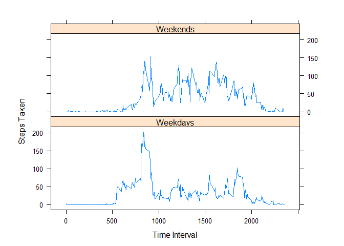

```r
    imputedData$date <- as.Date(imputedData$date)
    imputedData$dayOfTheWeek <- weekdays(imputedData$date)
    imputedData$weekend <- as.factor(ifelse(imputedData$dayOfTheWeek == "Saturday" |
                                             imputedData$dayOfTheWeek == "Sunday", "Weekends", "Weekdays"))
    plotdata <- aggregate(steps ~ interval + weekend, imputedData, mean)
    library(lattice)
    xyplot(steps ~ interval | factor(weekend), data=plotdata, aspect=1/3, xlab="Time Interval", ylab="Steps Taken", layout=c(1,2), type="l",)
```